# Introduction to StatComp18092

Guo Shiwei

2019-01-18

## Question

Write a .Rmd file to implement at least three examples of different types in the above books (texts, numerical results, tables, and figures).

## Answer

I will implement four simple examples of different types.

- figure

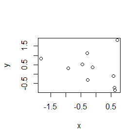

- numerical results

```
##  [1]  1  2  3  4  5  6  7  8  9 10
```

- text

```
##
## Call:
## lm(formula = a[, 1] ~ a[, 2])
##
## Residuals:
##        1        2        3        4
##  0.15620 -0.12590  0.07151 -0.10181
##
## Coefficients:
##             Estimate Std. Error t value Pr(>|t|)
## (Intercept)   0.9251     0.1442   6.414   0.0235 *
## a[, 2]       -1.1518     0.6874  -1.676   0.2358
## ---
## Signif. codes:  0 '***' 0.001 '**' 0.01 '*' 0.05 '.' 0.1 ' ' 1
##
## Residual standard error: 0.1669 on 2 degrees of freedom
## Multiple R-squared:  0.584,  Adjusted R-squared:  0.3761
## F-statistic: 2.808 on 1 and 2 DF,  p-value: 0.2358
```

- table

```
## x
##  1  2  3  4  5  6  7  8  9 10
##  2  3  7  5  6  7  3  1  4  2
```

The answer is good and there is no problem.

My R code is

set.seed(12345) x <- rnorm(10) y <- rnorm(10) plot(x, y)

seq(1,10)

a= matrix(runif(8),4,2) dimnames(a)=list(NULL,c(“x”,“y”)) summary(lm(a[,1]~a[,2]))

x <- rpois(40, lambda=5) table(x)

thank you for reading

## Question

3.5 A discrete random variable $X has probability mass function
$$\frac{x}{p(x)}\frac{0}{0.1}\frac{1}{0.2}\frac{2}{0.2}\frac{3}{0.2}\frac{4}{0.3}$$
Use the inverse transform method to generate a random sample of size 1000 from the distribution of X. Construct a relative frequency table and compare the empirical with the theoretical probabilities. Repeat using the R sample function.

3.7

Write a function to generate a random sample of size n from the Beta(a, b) distribution by the acceptance-rejection method. Generate a random sample of size 1000 from the Beta(3,2) distribution. Graph the histogram of the sample with the theoretical Beta(3,2) density superimposed.

3.12

## Answer

3.5

I will use inverse transformation in discrete distribution to solve this problem.

We can generate a random sample by inverse transform method:

```r
set.seed(12345);
# x
x=c(0,1,2,3,4);
# p
p=c(0.1,0.2,0.2,0.2,0.3);
cp=cumsum(p);
m=1000;r=numeric(m);
# inverse transform method
r=x[findInterval(runif(m),cp)+1];
r
```

```
##    [1] 4 4 4 4 2 1 2 3 4 4 0 1 4 0 2 2 2 2 1 4 2 2 4 4 3 2 3 3 1 2 4 0 1 3
##   [35] 2 2 4 4 3 1 4 2 4 4 1 2 0 0 0 3 4 4 2 1 4 2 4 0 2 1 4 1 4 4 4 1 4 1
##   [69] 3 4 3 3 2 2 0 3 4 3 3 1 4 3 0 0 1 2 4 3 4 0 4 4 0 3 4 3 4 4 0 2 1 3
##  [103] 4 3 3 4 3 4 1 1 3 2 4 2 4 4 4 3 0 2 3 3 0 3 4 4 4 1 1 4 0 3 4 3 4 4
##  [137] 3 1 0 4 3 3 1 3 1 4 4 2 4 2 4 3 4 2 1 4 3 2 4 3 4 3 4 4 2 2 4 1 4 2
##  [171] 4 1 4 2 2 4 4 4 4 4 1 2 1 1 4 4 2 4 1 1 4 4 2 2 4 0 1 4 1 2 3 4 1 3
##  [205] 3 4 0 0 3 3 1 3 2 1 4 2 2 3 3 1 1 1 0 3 4 4 4 2 2 3 2 3 2 3 4 3 4 4
##  [239] 2 2 4 4 4 4 3 3 4 3 2 4 1 4 0 1 4 4 0 1 1 2 4 4 4 4 4 0 1 4 4 3 1 2
##  [273] 1 4 4 2 3 0 2 4 1 4 0 0 1 2 0 4 3 3 4 4 0 2 4 1 4 1 3 0 0 3 4 3 3 3
##  [307] 1 1 2 2 2 2 4 1 2 4 3 3 1 4 2 3 3 2 2 4 2 0 1 1 2 4 4 3 1 0 4 4 2 4
##  [341] 3 3 4 4 3 3 4 4 0 4 3 3 4 3 3 4 3 3 0 4 1 1 2 1 2 4 4 1 4 3 3 4 4 3
##  [375] 3 2 2 4 2 2 4 4 2 3 4 4 3 1 4 0 4 4 4 1 2 1 2 2 3 1 0 2 1 1 3 1 4 1
##  [409] 4 0 3 4 0 0 4 4 3 2 2 1 4 1 1 1 2 4 4 2 1 3 3 0 4 2 0 3 0 4 3 1 4 4
##  [443] 0 3 2 4 2 0 4 4 4 2 2 4 3 3 4 1 3 0 3 4 1 4 3 2 3 2 4 1 2 2 4 3 1 2
##  [477] 4 4 3 1 1 1 1 3 2 3 1 4 2 4 4 4 4 3 2 2 4 4 4 4 1 4 4 4 3 4 0 3 2 4
##  [511] 4 2 2 3 2 3 1 1 1 4 4 1 4 3 2 1 2 3 4 4 2 2 3 3 3 4 1 4 1 2 1 2 1 3
##  [545] 4 3 0 3 3 4 4 2 3 4 2 1 1 0 3 2 0 0 3 3 1 1 4 3 4 1 3 3 3 1 1 2 4 1
##  [579] 4 3 2 4 1 2 2 3 3 4 1 0 3 1 0 4 1 3 1 4 3 4 3 0 3 4 2 4 4 4 2 2 3 1
##  [613] 4 1 3 0 2 3 4 1 1 4 2 1 4 4 4 3 4 2 2 2 1 0 0 2 4 1 1 1 3 3 4 2 4 3
##  [647] 3 4 0 3 4 2 3 3 3 4 1 2 4 1 4 0 3 4 3 2 4 1 3 3 3 0 0 4 4 1 3 2 3 0
##  [681] 4 1 2 4 4 3 4 4 2 4 2 4 1 0 4 4 0 4 4 2 3 2 2 1 0 4 1 4 4 2 2 4 3 2
##  [715] 3 2 3 4 1 1 2 0 0 0 3 0 2 0 3 3 4 3 3 4 4 3 4 1 2 4 2 0 4 4 3 0 4 2
##  [749] 4 4 1 4 4 2 0 1 4 4 4 0 2 1 2 3 3 4 1 4 3 1 2 4 4 2 4 2 1 0 2 4 4 2
##  [783] 3 3 3 4 2 2 3 2 3 1 4 0 3 4 2 2 0 2 4 4 3 0 3 1 1 1 1 1 4 2 2 3 2 4
##  [817] 1 4 1 3 1 3 2 4 4 1 3 4 1 0 2 3 3 2 1 2 1 3 4 3 3 1 3 3 1 3 3 1 4 2
##  [851] 2 4 4 2 1 2 4 3 4 3 1 0 2 4 3 3 1 0 3 4 3 1 4 3 4 2 4 0 4 1 3 2 4 2
##  [885] 3 4 4 2 4 0 3 1 1 0 0 1 3 2 1 1 4 1 4 2 1 0 2 3 4 1 4 1 4 4 2 4 1 2
##  [919] 3 2 0 4 2 3 3 1 1 0 2 4 1 3 1 4 1 3 0 2 2 3 4 3 2 4 0 4 4 3 4 3 2 2
##  [953] 1 1 2 2 2 1 2 2 2 3 2 3 2 3 3 2 0 4 3 4 4 4 3 3 3 2 3 4 1 2 4 4 2 2
##  [987] 0 4 2 0 3 1 1 3 1 4 2 1 2 1
```

By calcution, we wil get an elative frequency table:

```r
table(r)/m
```

```
## r
##     0     1     2     3     4
## 0.093 0.177 0.199 0.218 0.313
```

Using R sample function, we will get an another relative frequency table:

```r
a=sample(c(0,1,2,3,4),size=1000,replace=TRUE,prob=c(0.1,0.2,0.2,0.2,0.3));
table(a)/1000
```

```
## a
##     0     1     2     3     4
## 0.099 0.224 0.207 0.190 0.280
```

theoretical probabilities are:

```r
# theoretical probabilities
c(0.1,0.2,0.2,0.2,0.3)
```

```
## [1] 0.1 0.2 0.2 0.2 0.3
```

We find that they are similar. The answer is reasonable.

3.7

First, I will creat a function to generate a random sample using acceptance-rejection method. Then I will using this function to generate a random sample of size 1000 and graph the histogram of it.

The function is:

```r
get.beta=function(n,a,b){
  y=numeric(n)
  k=0
  while(k<n){
    u=runif(1,0,1/beta(a,b))
    x=runif(1)
    if(u<x^(a-1)*(1-x)^(b-1)/beta(a,b)){
      #we accept x
      k=k+1
      y[k]=x
    }
  }
  return(y)
}
```

generate a random simple of size 1000 from the Beta(3,2) distribution:

```r
# ues the function I just created
a=get.beta(1000,3,2)
a
```

```
##    [1] 0.4578478 0.7697757 0.6999145 0.9449553 0.4640286 0.7624432
##    [7] 0.2446607 0.5324479 0.7739790 0.9186360 0.6022072 0.5511563
##   [13] 0.3347412 0.3659745 0.9430204 0.3775094 0.8118346 0.7895681
##   [19] 0.7302311 0.7473009 0.9578598 0.6029672 0.2641025 0.6965469
##   [25] 0.7429009 0.7967362 0.5883118 0.4033990 0.5006497 0.5029776
##   [31] 0.6327080 0.7320820 0.7815213 0.4687478 0.5755680 0.5130378
##   [37] 0.3217781 0.5123951 0.8094356 0.6614758 0.6197908 0.8313120
##   [43] 0.7009846 0.5307307 0.8034642 0.3731900 0.4187686 0.8389895
##   [49] 0.4413062 0.6761481 0.9160300 0.6299933 0.4094396 0.5899135
##   [55] 0.6080707 0.5349854 0.4803662 0.5127571 0.1491237 0.5725205
##   [61] 0.7933691 0.8282804 0.7577026 0.1954568 0.4490412 0.8033197
##   [67] 0.5802189 0.2709804 0.8179400 0.9047577 0.2244381 0.5516709
##   [73] 0.5878063 0.5054890 0.8884102 0.5236222 0.8822473 0.8729198
##   [79] 0.6928481 0.7510120 0.7494651 0.7491769 0.7698602 0.2993368
##   [85] 0.7303784 0.7079438 0.6066068 0.8787144 0.7137869 0.8052462
```

[output cut: 152 more lines]

The histogram of the sample is:

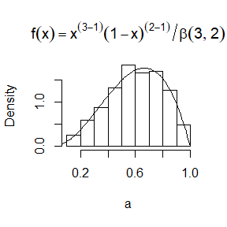

```r
# Graph the histogram
hist(a,probability = TRUE , main = expression(f(x)==x^(3-1)*(1-x)^(2-1)/beta(3,2)))
x=seq(0,1,0.01)
lines(x,x^(3-1)*(1-x)^(2-1)/beta(3,2))
```

The histogram of the sample is similar the theoretical Beta(3,2). It is reasonable.

3.12

I will generate 1000 random obserbations from thie mixture $r=4$ and $\beta=2$ . First generate the rate parameter, then generate random observations.

Generate the rate parameter, then generate random observations:

```r
r=4;
beta=2;
# n is the number of random observations
n=1000;
# generate a from gamma distribution
a=rgamma(n,r,beta)
# generate x from exp distribution
x=rexp(n,a)
# print random observations
x
```

```
##    [1] 6.466707e-01 2.322308e+00 5.585475e-01 1.999282e+00 1.134586e+00
##    [6] 1.352588e+00 1.709565e+00 2.105008e-02 1.488316e-01 1.013900e+00
##   [11] 2.583744e-01 4.859855e-01 2.244814e-01 6.225886e-01 1.931817e-01
##   [16] 5.507652e-01 8.886473e-01 1.336041e+00 5.732741e-02 3.278172e-01
##   [21] 2.073416e-01 1.219196e+00 1.152002e-02 3.723210e-01 9.493069e-02
##   [26] 4.421617e-01 5.316183e-02 4.126236e-01 8.679736e-01 7.006135e-02
##   [31] 9.029525e-01 9.019400e-01 4.966450e-01 5.768311e-02 2.087622e-01
##   [36] 2.228901e-02 2.367155e+00 1.155944e+00 2.569432e-01 2.462173e-02
##   [41] 2.267576e-01 1.362144e-01 2.882909e-04 4.387852e+00 1.921157e-01
##   [46] 3.088763e+00 8.871947e-02 2.838922e-01 4.621641e-01 7.359271e-01
##   [51] 1.710420e-01 3.887325e-01 6.892069e-01 3.143757e-01 4.384441e-01
##   [56] 1.403606e+00 5.018551e-01 5.793581e-01 5.007305e-01 1.385235e+00
##   [61] 4.102583e+00 8.698929e-01 9.841299e-02 1.961120e+00 2.221057e-01
##   [66] 2.038378e+00 6.728311e-02 2.796437e-02 5.581762e-02 7.675886e-01
##   [71] 6.150326e-01 3.837945e-01 4.482316e-01 1.917176e-02 2.536241e-01
```

[output cut: 185 more lines]

the histogram of it is:

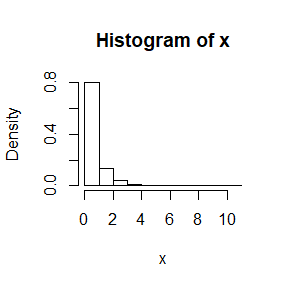

```r
hist(x,probability = TRUE )
```

It is good.

thank you for reading

## Question 1

5.4

Write a function to compute a Monte Carlo estimate of the Beta(3, 3) cdf, and use the function to estimate $F(x)$ for x = 0.1, 0.2, . . . , 0.9. Compare the estimates with the values returned by the$pbeta$ function in R.

## Answer 1

5.4

“cdf” means Cumulative Distribution Function.

First, write the function

```r
set.seed(12345)
cdf.beta=function(x){
  n=1e4
  t=runif(n,0,x)
  a=mean(t^2*(1-t)^2/beta(3,3))*x #Use a frequency to approximation the expectation
  return(a)
}
```

Draw the estimate function and $Beta(3,3)$ cdf

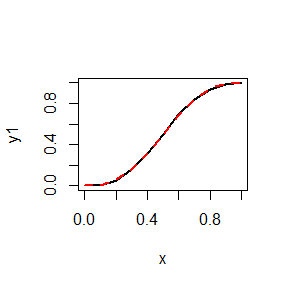

```r
x=seq(0,1,.1)
y1=numeric(10)
for(i in seq(0,1,.1)){
  y1[i*10+1]=cdf.beta(i)
}
y2=pbeta(x,3,3)
plot(x,y1,type = "l",lwd=2,xlim=c(0,1))
lines(x, y2, lty = 2,lwd=2, col=2)
```

Black line is estimate function, red line is Cumulative Distribution Function of $Beta(3,3)$, estimate function is good.

Estimate $F(x)$ for x = 0.1, 0.2, . . . , 0.9 . The estimations are:

```r
a=numeric(9)
for(i in seq(1,9,1)){
  a[i]=cdf.beta(i/10) # use the function to estimate F(x) for x = 0.1, 0.2, . . . , 0.9
}
a
```

```
## [1] 0.008405925 0.058185856 0.164062176 0.315034421 0.501537914 0.679220967
## [7] 0.834223079 0.941787481 0.983411345
```

Next get the real values using pbeta function. The real values are:

```r
b=a=numeric(9)
for(i in seq(1,9,1)){
  b[i]=pbeta(i/10,3,3) #use pbeta function
}
b
```

```
## [1] 0.00856 0.05792 0.16308 0.31744 0.50000 0.68256 0.83692 0.94208 0.99144
```

We find that they are similar.

## Question 2

5.9

The Rayleigh density [156, (18.76)] is
$$f(x)=\frac{x}{\sigma^2} e^{-x^2/(2\sigma^2)} , x\geq0,\sigma\geq0.$$
Implement a function to generate samples from a Rayleigh($\sigma$)distribution, using antithetic variables. What is the percent reduction in variance of $\frac{X+X'}{2}$ compared with $\frac{X_1+X_2}{2}$ for independent $X_1,X_2$ ?

## Answer 2

5.9

The Cumulative Distribution Function of $f(x)$ is:
$$F(x)=1-e^{-x^2/2\sigma^2}$$
so $F^{-1}$ is:
$$F^{-1}(u)=\sqrt{-2\sigma^2ln(1-u)}$$

Creat a function to generate samples from a Rayleigh($\sigma$)distribution, using antithetic variables. The functino is:

```r
anti.sample=function(a,  n=1e4, antithetic = TRUE){
  u <- runif(n/2,0,1)
  if (!antithetic) v <- runif(n/2) else v <- 1 - u # use antithetic variables
  u <- c(u, v)
  x=sqrt(-2*a^2*log(1-u)) #Inverse transformation
  return(x)
}
```

Then test the function, use the function to generate 10000 samples which $\sigma=3$

```r
x=anti.sample(3)
```

The histogram of it is:

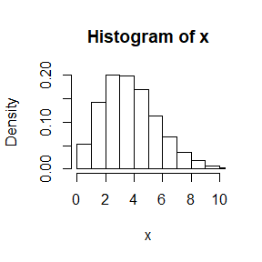

```r
hist(x,xlim=c(0,10),probability = TRUE )
```

Add probability density function

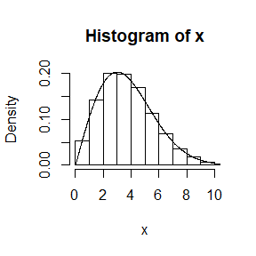

```r
hist(x,xlim=c(0,10),probability = TRUE )
x=seq(0,10,.01)
a=3
y=x/a^2*exp(-x^2/(2*a^2)) #probability density function
lines(x,y)
```

So the function is good

$\sigma=3$,variance of $\frac{X+X'}{2}$ and variance of $\frac{X_1+X_2}{2}$ for independent $X_1,X_2$ is

```r
x1=anti.sample(3)
v1=var((x1[1:(length(x1)/2)]+x1[(length(x1)/2+1):length(x1)])/2)

x2=anti.sample(3, antithetic = FALSE)
v2=var((x2[1:(length(x2)/2)]+x2[(length(x2)/2+1):length(x2)])/2)
c(v1,v2)
```

```
## [1] 0.09702257 1.95745003
```

the percent reduction is

```r
(v2-v1)/v2
```

```
## [1] 0.9504342
```

So we can see that the variance decrease a lot by using antithetic variables.

## Question 3

5.13

Find two importance functions $f_1$ and $f_2$ that are supported on $(1,\infty)$ and are ??close?? to
$$f(x)=\frac{x^2}{\sqrt{2\pi}} e^{-x^2/2} , x>1.$$
Which of your two importance functions should produce the smaller variance in estimating
$$\int_1^\infty\frac{x^2}{\sqrt{2\pi}} e^{-x^2/2}dx$$
by importance sampling? Explain.

## Answer 3

5.13

First draw $g(x)$

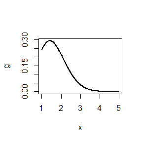

```r
x <- seq(1, 5, .01)
g=x^2/sqrt(2*pi)*exp(-x^2/2) #g(x)
plot(x,g,type = "l",lwd=2,xlim=c(1,5))
```

I definite:
$$f_1(x)=\frac{1}{\pi}[\frac{1.1}{(x-1.4)^2+1.1^2}]$$
$$f_2(x)=\frac{1}{\sqrt{2\pi}*\sqrt{0.8}} exp(-\frac{(x-1.4)^2}{2*0.8})$$

Draw $f_1$ and $0.6*f_2$

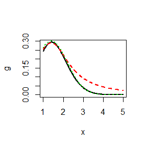

```r
x <- seq(1, 5, .01)
g=x^2/sqrt(2*pi)*exp(-x^2/2) #g(x)
plot(x,g,type = "l",lwd=2,xlim=c(1,5))
f1=dcauchy(x,1.4,1.1) #f1(x)
lines(x, f1, lty = 2,lwd=2, col=2)
f2=dnorm(x,1.4,.8)*.6 #f2(x)
lines(x, f2, lty = 3,lwd=2,col=3)
```

The red line is $f_1$, the green line is $0.6*f_2$

Because $0.6*f_2$ is more similar to $g$ than $f_1$.

I think $f_2$ should produce the smaller variance in estimating

## Question 4

5.14

Obtain a Monte Carlo estimate of
$$\int_1^\infty\frac{x^2}{\sqrt{2\pi}} e^{-x^2/2}dx$$
by importance sampling.

## Answer 4

5.14

Use the conclusion of 5.13, make
$$f(x)=\frac{1}{\sqrt{2\pi}*\sqrt{0.8}} exp(-\frac{(x-1.4)^2}{2*0.8})$$
So $f(x)$ is a probability density function.

Generate 100000 random samples and estimate integrationis

```r
n=1e5
x=rnorm(n,1.4,.8)
g=x^2/sqrt(2*pi)*exp(-x^2/2)*I(x>1) #g(x)
f=dnorm(x,1.4,0.8) #f(x)
fg=g/f #g(x)/f(x)
```

the expection and the variance of estimation is

```r
c(mean(fg),var(fg)) # estimation and variance of estimation
```

```
## [1] 0.40128336 0.07179143
```

It is good.

## Question 1

6.9

Let $X$ be a non-negative random variable with $\mu=E[X]<\infty$. For a random sample $x_1,...,x_n$ from the distribution of $X$. the Gini ratio is defined by
$$G=\frac{1}{2n^2\mu}\sum_{j=1}^n\sum_{i=1}^n|x_i-x_j|.$$
The Gini ratio is applied in economics to measure inequality in income distribution (see e.g. [163]). Note that $G$ can be written in terms of the order statistics $x_{(i)}$ as
$$G=\frac{1}{n^2\mu}\sum_{i=1}^n(2i-n-1)x_{(i)}.$$
If the mean is unknown, let $\hat{G}$ be the statistic $G$ with $\mu$ replaced by $\bar{x}$. Estimate by simulation the mean, median and deciles of$\hat{G}$ if $X$ is standard lognormal. Repeat the procedure for the uniform distribution and Bernoulli(0.1). Also construct density histograms of the replicates in each case.

## Answer 1

6.9

First, if $X$ is standard lognormal, we creat samples of $X$, and get $\hat{G}$.

```r
set.seed(12345)
n=1e3
m=1e3
G=numeric(m)
for(i in 1:m){
  x=rlnorm(n) #lognormal
  G[i]=1/(n^2*mean(x))*sum((2*seq(1,n)-n-1)*x[order(x)]) # caculate gini ratio
}
```

The mean and median of $\hat{G}$ are

```r
c(mean(G),median(G))
```

```
## [1] 0.5203298 0.5209140
```

The deciles of $\hat{G}$ are

```r
quantile(G, probs = seq(0, 1, 0.1))
```

```
##        0%       10%       20%       30%       40%       50%       60%
## 0.4831437 0.5028949 0.5087575 0.5130648 0.5169577 0.5209140 0.5236524
##       70%       80%       90%      100%
## 0.5271461 0.5313873 0.5375566 0.5718241
```

Hist of $\hat{G}$ is

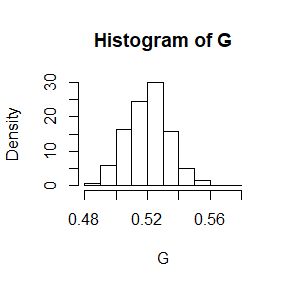

```r
hist(G,probability = TRUE )
```

If $X$ is uniform distribution, we creat samples of $X$, and get $\hat{G}$.

```r
G=numeric(m)
for(i in 1:m){
  x=runif(n) #uniform
  G[i]=1/(n^2*mean(x))*sum((2*seq(1,n)-n-1)*x[order(x)]) # caculate gini ratio
}
```

The mean and median of $\hat{G}$ are

```r
c(mean(G),median(G))
```

```
## [1] 0.3330377 0.3330919
```

The deciles of $\hat{G}$ are

```r
quantile(G, probs = seq(0, 1, 0.1))
```

```
##        0%       10%       20%       30%       40%       50%       60%
## 0.3113314 0.3229329 0.3263271 0.3293769 0.3311842 0.3330919 0.3352606
##       70%       80%       90%      100%
## 0.3375370 0.3392725 0.3424776 0.3637629
```

Hist of $\hat{G}$ is

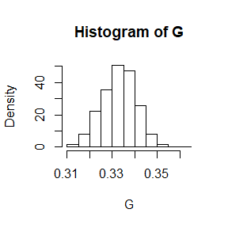

```r
hist(G,probability = TRUE )
```

If $X$ is $Bernoulli(0.1)$, we creat samples of $X$, and get $\hat{G}$.

```r
G=numeric(m)
for(i in 1:m){
  x=rbinom(n, 1, 0.1) #bernoulli
  G[i]=1/(n^2*mean(x))*sum((2*seq(1,n)-n-1)*x[order(x)]) # caculate gini ratio
}
```

The mean and median of $\hat{G}$ are

```r
c(mean(G),median(G))
```

```
## [1] 0.900015 0.900000
```

The deciles of $\hat{G}$ are

```r
quantile(G, probs = seq(0, 1, 0.1))
```

```
##    0%   10%   20%   30%   40%   50%   60%   70%   80%   90%  100%
## 0.865 0.887 0.892 0.895 0.897 0.900 0.903 0.906 0.908 0.912 0.930
```

Hist of $\hat{G}$ is

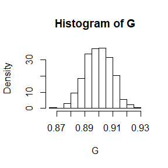

```r
hist(G,probability = TRUE )
```

I find gini ratio of uniform(0,1) is smaller, gini ratio of Bernoulli(0.1) is bigger.

## Question 2

6.10

Construct an approximate 95% confidence interval for the Gini ratio $\gamma=E[G]$ if $X$ is lognormal with unknown parameters. Assess the coverage rate of the estimation procedure with a Monte Carlo experiment.

## Answer 2

6.10

Creat a function to caculate 95% confidence interval for the Gini ratio $\gamma=E[G]$ if X~lognormal(me,s)

```r
m <- 1e3; n <- 1e3;
confi.interval=function(me,s){
  g.hat=numeric(m)
  for(i in 1:m){
    x <- rlnorm(n,me,s) #lognormal
    g.hat[i]=1/(n^2*mean(x))*sum((2*seq(1,n)-n-1)*x[order(x)]) #caculate Gini ratio
  }
  a=quantile(g.hat, probs = 0.025,names=FALSE)
  b=quantile(g.hat, probs = 0.975,names=FALSE)
  c(a,b) #95% confidence interva
}
```

Just consider lognormal(0,1) (meanlog = 0, sdlog = 1). We use the function to caculate the 95% confidence interval:

```r
me=0
s=1
c=confi.interval(me,s)
a=c[1]
b=c[2]
c #95% confidence interva
```

```
## [1] 0.4941257 0.5461620
```

Now, caculate the coverage rate of the estimation. The coverage rate is:

```r
I=numeric(m)
g.hat=numeric(m)
for(i in 1:m){
  x <- rlnorm(n,me,s) # lognormal
  g.hat[i]=1/(n^2*mean(x))*sum((2*seq(1,n)-n-1)*x[order(x)]) #caculate gini ratio
  if(g.hat[i]>a && g.hat[i]<b){ #see if it in 95% confidence interval
    I[i]=1 # in 95% confidence interval
  }
  else{
    I[i]=0 # not in 95% confidence interval
  }
}
mean(I)
```

```
## [1] 0.962
```

It is close to theoretical value

## Question 3

6.B

Tests for association based on Pearson product moment correlation $\rho$, Spearman??s rank correlation coefficient $\rho_s$, or Kendall??s coefficient $\tau$, are implemented in cor.test. Show (empirically) that the nonparametric tests based $\rho_s$ or $\tau$ are less powerful than the correlation test when the sampled distribution is bivariate normal. Find an example of an alternative (a bivariate $(X,Y)$ such that $X$ and $Y$ are dependent) such that at least one of the nonparametric tests have better empirical power than the correlation test against this alternative. distribution on

## Answer 3

6.B

(1)First when the sampled distribution is bivariate normal, We make X and Y are bivariate normal, and $\mu(x)=\mu(Y)=0, var(X)=var(Y)=1, cov(X,Y)=0.5$

```r
library(MASS)
a <- mvrnorm(1e2,rep(0,2),matrix(c(1,0.5,0.5,1),2))
x=a[,1]
y=a[,2]
cor.test(x,y,method = "pearson")
```

```
##
##  Pearson's product-moment correlation
##
## data:  x and y
## t = 5.793, df = 98, p-value = 8.378e-08
## alternative hypothesis: true correlation is not equal to 0
## 95 percent confidence interval:
##  0.3426341 0.6381713
## sample estimates:
##       cor
## 0.5050618
```

```r
cor.test(x,y,method = "spearman")
```

```
##
##  Spearman's rank correlation rho
##
## data:  x and y
## S = 93708, p-value = 6.591e-06
## alternative hypothesis: true rho is not equal to 0
## sample estimates:
##       rho
## 0.4376958
```

```r
cor.test(x,y,method = "kendall")
```

```
##
##  Kendall's rank correlation tau
##
## data:  x and y
## z = 4.485, p-value = 7.29e-06
## alternative hypothesis: true tau is not equal to 0
## sample estimates:
##       tau
## 0.3042424
```

We can find that Pearson product moment correlation is much close to the true value.So the nonparametric tests are less powerful than the correlation test when the sampled distribution is bivariate normal.

(2)When X and Y are dependent. The example is that we make X~exp(1), Z~ P(Z=1000)=0.1, P(Z=0)=0.9 and Y=X+Z, X and Y are dependent, so the theoretical value of correlation is not equal to 0, and should much bigger than 0.

We now caculate Pearson product moment correlation, Spearman??s rank correlation coefficient and Kendall??s coefficient.

```r
x=rexp(1e3) #X~exp(1)
z=sample(c(0,1e3), size=1e3, replace = TRUE, prob = c(0.9,0.1))
y=x+z

cor.test(x,y,method = "pearson")
```

```
##
##  Pearson's product-moment correlation
##
## data:  x and y
## t = 0.010409, df = 998, p-value = 0.9917
## alternative hypothesis: true correlation is not equal to 0
## 95 percent confidence interval:
##  -0.06166487  0.06232129
## sample estimates:
##          cor
## 0.0003294759
```

```r
cor.test(x,y,method = "spearman")
```

```
##
##  Spearman's rank correlation rho
##
## data:  x and y
## S = 27259000, p-value < 2.2e-16
## alternative hypothesis: true rho is not equal to 0
## sample estimates:
##       rho
## 0.8364488
```

```r
cor.test(x,y,method = "kendall")
```

```
##
##  Kendall's rank correlation tau
##
## data:  x and y
## z = 39.467, p-value < 2.2e-16
## alternative hypothesis: true tau is not equal to 0
## sample estimates:
##       tau
## 0.8335015
```

We find that Spearman??s rank correlation coefficient and Kendall??s coefficient are much bigger than 0. Pearson product moment correlation is close to 0.Then we see the p-value, the p-value of tow nonparametric tests are smaller and p-value of Pearson test is bigger. So in this example, two nonparametric tests both have better empirical power than the correlation test.

## Question 1

7.1

Compute a jackknife estimate of the bias and the standard error of the correlation statistic in Example 7.2.

## Answer 1

7.1

first, input the data

```r
library(bootstrap)
set.seed(1)
x=matrix(c(576,635,558,578,666,580,555,661,651,605,653,575,545,572,594,339,330,281,303,344,307,300,343,336,313,312,274,276,288,296),ncol=2)
x #print x
```

```
##       [,1] [,2]
##  [1,]  576  339
##  [2,]  635  330
##  [3,]  558  281
##  [4,]  578  303
##  [5,]  666  344
##  [6,]  580  307
##  [7,]  555  300
##  [8,]  661  343
##  [9,]  651  336
## [10,]  605  313
## [11,]  653  312
## [12,]  575  274
## [13,]  545  276
## [14,]  572  288
## [15,]  594  296
```

then, calculate the bias and the standard error

```r
b.cor <- function(x,i) cor(x[i,1],x[i,2])
n=nrow(x) #length
theta.hat <- b.cor(x,1:n)
theta.jack <- numeric(n)
for(i in 1:n){
  theta.jack[i] <- b.cor(x,(1:n)[-i]) #jackknife
}
bias.jack <- (n-1)*(mean(theta.jack)-theta.hat) #bias
se.jack <- sqrt((n-1)*mean((theta.jack-theta.hat)^2)) #se
round(c(bias=bias.jack, se=se.jack),3) # estimation, bias and the standard error
```

```
##   bias     se
## -0.006  0.143
```

## Question 2

7.5

Refer to Exercise 7.4. Compute 95% bootstrap confidence intervals for the mean time between failures $1/\lambda$ by the standard normal, basic, percentile, and BCa methods. Compare the intervals and explain why they may differ.

## Answer 2

7.5

Compute 95% bootstrap confidence intervals

```r
library(boot)
theta.boot <- function(dat,i) {
#function to compute the statistic
  y <- dat[i, 1]
  mean(y)
}
boot.obj <- boot(aircondit, statistic = theta.boot, R = 2000)
print(boot.ci(boot.obj,type = c("norm","basic",  "perc","bca")))
```

```
## BOOTSTRAP CONFIDENCE INTERVAL CALCULATIONS
## Based on 2000 bootstrap replicates
##
## CALL :
## boot.ci(boot.out = boot.obj, type = c("norm", "basic", "perc",
##     "bca"))
##
## Intervals :
## Level      Normal              Basic
## 95%   ( 33.8, 181.2 )   ( 25.6, 172.1 )
##
## Level     Percentile            BCa
## 95%   ( 44.1, 190.6 )   ( 55.2, 229.3 )
## Calculations and Intervals on Original Scale
```

They are different. The intervals of Basic are smaller, the intervals of BCa are bigger.

I think it is because the model are not same, so the ways of generating data and calculations are different.So the results are different.

## Question 3

7.8

Refer to Exercise 7.7. Obtain the jackknife estimates of bias and standard error of $\hat{\theta}$

## Answer 3

7.8

compute the jackknife estimates of bias and standard error

```r
pca <- function(x,i){
  lambda1=rev(sort(eigen(cov(x[i,]))$values))[1]
  sig=sum(rev(sort(eigen(cov(x[i,]))$values)))
  lambda1/sig
}
x=scor
n=nrow(x) #length
theta.hat <- pca(x,1:n)
theta.jack <- numeric(n)
for(i in 1:n){
  theta.jack[i] <- pca(x,(1:n)[-i]) #jackknife
}
bias.jack <- (n-1)*(mean(theta.jack)-theta.hat) #bias
se.jack <- sqrt((n-1)*mean((theta.jack-theta.hat)^2)) #se
round(c(bias=bias.jack, se=se.jack),3) # estimation, bias and the standard error
```

```
##  bias    se
## 0.001 0.050
```

## Question 4

7.11

In Example 7.18, leave-one-out (n-fold) cross validation was used to select the best fitting model. Use leave-two-out cross validation to compare the models.

## Answer 4

7.11

First, use leave-one-out cross validation to compare the models

```r
library(DAAG,quietly=TRUE)
attach(ironslag)
    n <- length(magnetic)   #in DAAG ironslag
    e1 <- e2 <- e3 <- e4 <- numeric(n)

    # for n-fold cross validation
    # fit models on leave-one-out samples
    for (k in 1:n) {
        y <- magnetic[-k]
        x <- chemical[-k]

        J1 <- lm(y ~ x)
        yhat1 <- J1$coef[1] + J1$coef[2] * chemical[k]
        e1[k] <- magnetic[k] - yhat1

        J2 <- lm(y ~ x + I(x^2))
        yhat2 <- J2$coef[1] + J2$coef[2] * chemical[k] +
                J2$coef[3] * chemical[k]^2
        e2[k] <- magnetic[k] - yhat2

        J3 <- lm(log(y) ~ x)
        logyhat3 <- J3$coef[1] + J3$coef[2] * chemical[k]
        yhat3 <- exp(logyhat3)
        e3[k] <- magnetic[k] - yhat3

        J4 <- lm(log(y) ~ log(x))
        logyhat4 <- J4$coef[1] + J4$coef[2] * log(chemical[k])
        yhat4 <- exp(logyhat4)
        e4[k] <- magnetic[k] - yhat4
    }

    c(mean(e1^2), mean(e2^2), mean(e3^2), mean(e4^2))
```

```
## [1] 19.55644 17.85248 18.44188 20.45424
```

MSE of model 2 are smaller, so the best model is model two.

then, use leave-two-out cross validation to compare the models

```r
library(DAAG)
    n <- length(magnetic);   #in DAAG ironslag
    e1 <- e2 <- e3 <- e4 <- numeric(n)

    # for n-fold cross validation
    # fit models on leave-one-out samples
    for (k in 1:n) {
      for(j in 1:n){
        y <- magnetic[c(-k,-j)]
        x <- chemical[c(-k,-j)]

        J1 <- lm(y ~ x)
        yhat1 <- J1$coef[1] + J1$coef[2] * chemical[k]
        e1[k] <- magnetic[k] - yhat1

        J2 <- lm(y ~ x + I(x^2))
        yhat2 <- J2$coef[1] + J2$coef[2] * chemical[k] +
                J2$coef[3] * chemical[k]^2
        e2[k] <- magnetic[k] - yhat2

        J3 <- lm(log(y) ~ x)
        logyhat3 <- J3$coef[1] + J3$coef[2] * chemical[k]
        yhat3 <- exp(logyhat3)
        e3[k] <- magnetic[k] - yhat3

        J4 <- lm(log(y) ~ log(x))
        logyhat4 <- J4$coef[1] + J4$coef[2] * log(chemical[k])
        yhat4 <- exp(logyhat4)
        e4[k] <- magnetic[k] - yhat4
    }
    }

    c(mean(e1^2), mean(e2^2), mean(e3^2), mean(e4^2))
```

```
## [1] 19.58175 17.91919 18.74389 20.80684
```

MSE of model 2 are smaller, so the best model is model two.

It is same as previous results.

## Question 1

8.1

Implement the two-sample Cram??er-von Mises test for equal distributions as a permutation test. Apply the test to the data in Examples 8.1 and 8.2.

## Answer 1

8.1

Use Cramer-von Mises test

```r
set.seed(1)
attach(chickwts)
x <- sort(as.vector(weight[feed == "soybean"]))
y <- sort(as.vector(weight[feed == "linseed"]))
detach(chickwts)
R <- 999 #number of replicates
z <- c(x, y) #pooled sample
K <- 1:26
D <- numeric(R) #storage for replicates

CM=function(x,y){
  lx=length(x)
  ly=length(y)
  s1=sum((ecdf(x)(x)-ecdf(y)(x))^2)
  s2=sum((ecdf(x)(y)-ecdf(y)(y))^2)
  return((lx*ly)/(lx+ly)^2*(s1+s2))
}

D0 <- CM(x,y)
for (i in 1:R) {
#generate indices k for the first sample
k <- sample(K, size = 14, replace = FALSE)
x1 <- z[k]
y1 <- z[-k] #complement of x1
D[i] <- CM(x1,y1)
}
```

p-value is

```r
p <- mean(c(D0, D) >= D0)
print(p)
```

```
## [1] 0.421
```

so accept H0, x and y are from same distribution.

## Question 2

Design experiments for evaluating the performance of the NN, energy, and ball methods in various situations.

Unequal variances and equal expectations Unequal variances and unequal expectations Non-normal distributions: t distribution with 1 df (heavy-tailed distribution), bimodel distribution (mixture of two normal distributions) Unbalanced samples (say, 1 case versus 10 controls) Note: The parameters should be choosen such that the powers are distinguishable (say, range from 0.3 to 0.9).

## Answer 2

We can compare the p-value

first design compare function

```r
library(RANN)
library(energy)
library(Ball)
library(boot)

com=function(x,y){
  z <- c(x, y)
  Tn <- function(z, ix, sizes,k) {
  n1 <- sizes[1]; n2 <- sizes[2]; n <- n1 + n2
  if(is.vector(z)) z <- data.frame(z,0);
  z <- z[ix, ];
  NN <- nn2(data=z, k=k+1) # what's the first column?
  block1 <- NN$nn.idx[1:n1,-1]
  block2 <- NN$nn.idx[(n1+1):n,-1]
  i1 <- sum(block1 < n1 + .5); i2 <- sum(block2 > n1+.5)
  (i1 + i2) / (k * n)
  }
  set.seed(12345); N <- c(length(x), length(y))
  boot.obj <- boot(data = z, statistic = Tn, R = 999,
  sim = "permutation", sizes = N,k=3)
  ts <- c(boot.obj$t0,boot.obj$t)
  pnn.value <- mean(ts>=ts[1])

  boot.obs <- eqdist.etest(z, sizes=N, R=999)
  pen.value <- boot.obs$p.value

  pba.value = bd.test(x = x, y = y, R=999)$p.value
  return(c(pnn.value, pen.value, pba.value))
}
```

now use this function to compare three methods.

1.Unequal variances and equal expectations

```r
x=rnorm(100,0,1)
y=rnorm(100,0,1.1)
com(x,y)
```

```
##                     bd.pvalue
## 0.9680000 0.5470000 0.3535354
```

in this situation, ball is better

2.Unequal variances and unequal expectations

```r
x=rnorm(100,0,1)
y=rnorm(100,0.1,1.1)
com(x,y)
```

```
##                        bd.pvalue
## 0.39300000 0.05400000 0.01010101
```

in this situation, ball is better

3.Non-normal distributions: t distribution with 1 df (heavy-tailed distribution), bimodel distribution (mixture of two normal distributions)

```r
x=rt(100,1)
y=c(rnorm(50,0.1),rnorm(50,-0.1))
print(com(x,y))
```

```
##                     bd.pvalue
##     0.007     0.001     0.010
```

4,Unbalanced samples (say, 1 case versus 10 controls)

```r
x=rnorm(5,0,1)
y=rnorm(100,0,1.1)
com(x,y)
```

```
##                     bd.pvalue
## 0.2270000 0.1800000 0.1010101
```

## Question 3

9.3

Use the Metropolis-Hastings sampler to generate random variables from a standard Cauchy distribution. Discard the first 1000 of the chain, and compare the deciles of the generated observations with the deciles of the standard Cauchy distribution (see qcauchy or qt with df=1). Recall that a Cauchy($\theta$, $\eta$) distribution has density function

$$f(x)=\frac{1}{\theta \pi(1+[(\pi-\eta)/\theta]^2)}, -\infty<x<\infty, \theta>0$$
The standard Cauchy has the Cauchy($\theta$ = 1, $\eta$ = 0) density. (Note that the standard Cauchy density is equal to the Student t density with one degree of freedom.)

## Answer 3

9.3

Use the Metropolis-Hastings sampler to generate random variables from a standard Cauchy distribution.

```r
f <- function(x) {
  return(1/(pi*(1+x^2))) # standard Cauchy distribution
}

m <- 10000
x <- numeric(m)
x[1] <- rnorm(1)
u <- runif(m)

for (i in 2:m) {
  xt <- x[i-1]
  y <- rnorm(1,xt)
  num <- f(y) * dnorm(xt,y)
  den <- f(xt) * dnorm(y, xt)
  if (u[i] <= num/den) x[i] <- y else {
    x[i] <- xt
    k <- k+1     #y is rejected
  }
}

b <- 1001      #discard the burnin sample
y <- x[b:m]
a <- seq(-10,10,0.1)
```

hist it and Cauchy distribution

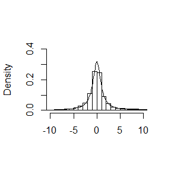

```r
hist(y, breaks="scott", main="", xlab="", freq=FALSE,xlim=c(-10,10),ylim=c(0,0.4))
lines(a, f(a))
```

compare the deciles

```r
quantile(y,probs=seq(0.1,0.9,0.1))
```

```
##         10%         20%         30%         40%         50%         60%
## -3.26220727 -1.52502920 -0.82960890 -0.42066521 -0.06073828  0.26356558
##         70%         80%         90%
##  0.63315577  1.27640581  2.98544814
```

```r
qcauchy(seq(0.1,0.9,0.1))
```

```
## [1] -3.0776835 -1.3763819 -0.7265425 -0.3249197  0.0000000  0.3249197
## [7]  0.7265425  1.3763819  3.0776835
```

it is similar

## Question 4

9.6

Rao [220, Sec. 5g] presented an example on genetic linkage of 197 animals in four categories (also discussed in [67, 106, 171, 266]). The group sizes are (125, 18, 20, 34). Assume that the probabilities of the corresponding multinomial distribution are

$$(\frac{1}{2}+\frac{\theta}{4},\frac{1-\theta}{4},\frac{1-\theta}{4},\frac{\theta}{4})$$

Estimate the posterior distribution of $\theta$ given the observed sample, using one of the methods in this chapter.

## Answer 4

estimate the $\theta$

```r
w <- .25 #width of the uniform support set
m <- 5000 #length of the chain
win=c(125,18,20,34)
x <- numeric(m) #the chain

prob <- function(y, win) {
  # computes (without the constant) the target density
  if (y < 0 || y >= 0.8)
  return (0)
  return((1/2+y/4)^win[1] *
  ((1-y)/4)^win[2] * ((1-y)/4)^win[3] *
  (y/4)^win[4] )
}

u <- runif(m) #for accept/reject step
v <- runif(m, -w, w) #proposal distribution
x[1] <- .25

for (i in 2:m) {
  y <- x[i-1] + v[i]
  if (u[i] <= prob(y, win) / prob(x[i-1], win))
  x[i] <- y else
  x[i] <- x[i-1]
}

index=1001:m
```

$\hat{\theta}$ is

```r
theta.hat=mean(x[index])
print(theta.hat)
```

```
## [1] 0.6210822
```

## Question 1

9.6

For exercise 9.6, use the Gelman-Rubin method to monitor convergence of the chain, and run the chain until the chain has converged approximately to the target distribution according to $\hat{R}<1.2$

## Answer 1

9.6

First, write Gelman-Rubin function. Then, use the Gelman-Rubin method to monitor convergence of the chain.

```r
set.seed(1)
Gelman.Rubin <- function(psi) {
  # psi[i,j] is the statistic psi(X[i,1:j])
  # for chain in i-th row of X
  psi <- as.matrix(psi)
  n <- ncol(psi)
  k <- nrow(psi)
  psi.means <- rowMeans(psi) #row means
  B <- n * var(psi.means) #between variance est.
  psi.w <- apply(psi, 1, "var") #within variances
  W <- mean(psi.w) #within est.
  v.hat <- W*(n-1)/n + (B/n) #upper variance est.
  r.hat <- v.hat / W #G-R statistic
  return(r.hat)
}

w <- .25 #width of the uniform support set
m <- 5000 #length of the chain
win=c(125,18,20,34)
x <- numeric(m) #the chain
prob <- function(y, win) {
  # computes (without the constant) the target density
  if (y < 0 || y >= 0.9)
  return (0)
  return((1/2+y/4)^win[1] *
  ((1-y)/4)^win[2] * ((1-y)/4)^win[3] *
  (y/4)^win[4] )
}

u <- runif(m) #for accept/reject step
v <- runif(m, -w, w) #proposal distribution
x[1] <- .25

this.chain <- function(win, N, X1) {
  #starting value X1
  x <- rep(0, N)
  x[1] <- X1
  u <- runif(N)

  for (i in 2:m) {
    y <- x[i-1] + v[i]
    if (u[i] <= prob(y, win) / prob(x[i-1], win))
    x[i] <- y else
    x[i] <- x[i-1]
  }
  return(x)
}

k <- 4 #number of chains to generate
n <- 5000 #length of chains
b <- 500 #burn-in length
#choose overdispersed initial values
x0 <- c(0.2, 0.4, 0.6, 0.8)
#generate the chains
X <- matrix(0, nrow=k, ncol=n)
for (i in 1:k)
  X[i, ] <- this.chain(win, n, x0[i])

psi <- t(apply(X, 1, cumsum))
for (i in 1:nrow(psi))
psi[i,] <- psi[i,] / (1:ncol(psi))
print(Gelman.Rubin(psi))
```

```
## [1] 1.046847
```

```r
#plot psi for the four chains
par(mfrow=c(2,2))
#for (i in 1:k)
#plot(psi[i, (b+1):n], type="l",
#xlab=i, ylab=bquote(psi))
par(mfrow=c(1,1)) #restore default
#plot the sequence of R-hat statistics
rhat <- rep(0, n)
for (j in (b+1):n)
rhat[j] <- Gelman.Rubin(psi[,1:j])
#plot(rhat[(b+1):n], type="l", xlab="", ylab="R")
#abline(h=1.1, lty=2)
```

We can see that we have run the chain until the chain has converged approximately to the target distribution according to$\hat{R}<1.2$

## Question 2

11.4

Find the intersection points $A(k)$ in $(0,\sqrt{k}$ of the curves

$$S_{k-1}(a)=P(t(k-1)>\sqrt{\frac{a^2(k-1)}{k-a^2}})$$

and

$$S_{k}(a)=P(t(k)>\sqrt{\frac{a^2k}{k+1-a^2}})$$

for k = 4 : 25, 100, 500, 1000, where t(k) is a Student t random variable with k degrees of freedom. (These intersection points determine the critical values for a t-test for scale-mixture errors proposed by Sz??ekely [260].)

## Answer 2

Use uniroot function to get the intersection points’ abscissa.

```r
u=c(seq(4,25),100,500,1000)
b=numeric(length(u))
c=numeric(length(u))
s1=function(a){   #S_k-1
  1-pt(sqrt(a^2*(k-1)/(k-a^2)),k-1)
}
s2=function(a){   #S_k
  1-pt(sqrt(a^2*k/(k+1-a^2)),k)
}
s=function(a){   #s1-s2
  1-pt(sqrt(a^2*(k-1)/(k-a^2)),k-1)-(1-pt(sqrt(a^2*k/(k+1-a^2)),k))
}
for(i in 1:length(u)){
  k=u[i]
  b[i]=uniroot(s,c(0.01,2))$root    #get root
  c[i]=s1(b[i])
}
```

the result is:

```r
matrix(c(u,b,c),length(u))
```

```
##       [,1]     [,2]       [,3]
##  [1,]    4 1.492103 0.07381507
##  [2,]    5 1.533554 0.06627626
##  [3,]    6 1.562745 0.06156861
##  [4,]    7 1.584430 0.05835931
##  [5,]    8 1.601185 0.05603419
##  [6,]    9 1.614522 0.05427354
##  [7,]   10 1.625391 0.05289475
##  [8,]   11 1.634420 0.05178611
##  [9,]   12 1.642039 0.05087552
## [10,]   13 1.648555 0.05011438
## [11,]   14 1.654192 0.04946876
## [12,]   15 1.659115 0.04891427
## [13,]   16 1.663454 0.04843290
## [14,]   17 1.667305 0.04801112
## [15,]   18 1.670747 0.04763852
## [16,]   19 1.673841 0.04730698
## [17,]   20 1.676638 0.04701007
## [18,]   21 1.679179 0.04674264
## [19,]   22 1.681497 0.04650052
## [20,]   23 1.683621 0.04628027
## [21,]   24 1.685573 0.04607906
## [22,]   25 1.687374 0.04589453
## [23,]  100 1.720606 0.04266897
## [24,]  500 1.729753 0.04183751
## [25,] 1000 1.730905 0.04173444
```

The first col is k, the second and third col is intersection points’ abscissa and Y-axis.

## Question 1

11.6

Write a function to compute the cdf of the Cauchy distribution, which has density

$$\frac{1}{\theta\pi(1+[(\pi-\eta)/\theta]^2)}, -\infty<x<\infty,$$

where$\theta$ > 0. Compare your results to the results from the R function pcauchy. (Also see the source code in pcauchy.c.)

## Answer 1

11.6

Just integrate cdf, we can get pdf

```r
set.seed(1)
f=function(x,eta=0,theta=1){   # function
  return(1/(theta*pi*(1+((x-eta)/theta)^2)))
}

res <- function(y,eta1=0,theta1=1){  #integrate
  integrate(f, lower=-Inf, upper=y, rel.tol=.Machine$double.eps^0.25,eta=eta1,theta=theta1)$value
}
```

Check it

```r
res(-2)
```

```
## [1] 0.1475836
```

```r
pcauchy(-2)
```

```
## [1] 0.1475836
```

```r
res(0)
```

```
## [1] 0.5
```

```r
pcauchy(0)
```

```
## [1] 0.5
```

```r
res(-2,2,3)
```

```
## [1] 0.2048328
```

```r
pcauchy(-2,2,3)
```

```
## [1] 0.2048328
```

The results are good.

## Question 2

A-B-O blood type problem

Let the three alleles be A, B, and O.

Observed data: nA?? = nAA + nAO = 28 (A-type), nB?? = nBB + nBO = 24 (B-type), nOO = 41 (O-type), nAB = 70 (AB-type).

Use EM algorithm to solve MLE of p and q (consider missing data nAA and nBB).

Record the maximum likelihood values in M-steps, are they increasing?

## Answer 2

Use EM algorithm to solve MLE of p and q

```r
library('nloptr')
library(lpSolve);suppressMessages(library(quantreg))
N=1000
na=28
nb=24
noo=41
nab=70
p=0.6   #initial est. for p
q=0.3
r=0.1
pm=numeric(0)
qm=numeric(0)
rm=numeric(0)
lofm=numeric(0)
lof=function(p,q,r){   #log maximum likelihood values
  return(log(choose(n,naa)*choose(n-naa,nbb)*choose(n-naa-nbb,noo)*choose(nao+nbo+nab,nao)*choose(nbo+nab,nbo))+(nao+nbo+nab)*log(2)+(2*naa+nao+nab)*log(p)+(2*nbb+nbo+nab)*log(q)+(2*noo+nao+nbo)*log(r))
}
for (j in 1:N) {
  naa=round(na*p^2/(p^2+2*p*r))
  nbb=round(nb*q^2/(q^2+2*q*r))
  nao=na-naa
  nbo=nb-nbb
  n=naa+nbb+noo+nao+nbo+nab
  if(abs(p-(2*naa+nao+nab)/2/n)<0.000000001&&abs(q-(2*nbb+nbo+nab)/2/n)<0.000000001&&abs(r-(2*noo+nbo+nao)/2/n)<0.000000001&&j>5) break
  p=(2*naa+nao+nab)/2/n  #update estimation
  q=(2*nbb+nbo+nab)/2/n
  r=(2*noo+nbo+nao)/2/n
  pm=c(pm,p)
  qm=c(qm,q)
  rm=c(rm,r)
  lofm=c(lofm,lof(p,q,r))
}
```

the resualt p,q,r is:

```r
c(p,q,r)
```

```
## [1] 0.3282209 0.3098160 0.3619632
```

in M-steps, the maximum likelihood values is:

```r
exp(lofm)
```

```
## [1] 6.864600e-29 1.798439e-23 2.908277e-23 2.908277e-23 2.908277e-23
```

they are increasing

## Question 1

3

Use both for loops and lapply() to fit linear models to the mtcars using the formulas stored in this list: formulas <- list( mpg ~ disp, mpg ~ I(1 / disp), mpg ~ disp + wt, mpg ~ I(1 / disp) + wt )

## Answer 1

3

use lapply

```r
formulas <- list(
mpg ~ disp,
mpg ~ I(1 / disp),
mpg ~ disp + wt,
mpg ~ I(1 / disp) + wt
)

a=lapply(formulas,function(i){lm(i,mtcars)})
a
```

```
## [[1]]
##
## Call:
## lm(formula = i, data = mtcars)
##
## Coefficients:
## (Intercept)         disp
##    29.59985     -0.04122
##
##
## [[2]]
##
## Call:
## lm(formula = i, data = mtcars)
##
## Coefficients:
## (Intercept)    I(1/disp)
##       10.75      1557.67
##
##
## [[3]]
##
## Call:
## lm(formula = i, data = mtcars)
##
## Coefficients:
## (Intercept)         disp           wt
##    34.96055     -0.01772     -3.35083
##
##
## [[4]]
##
## Call:
## lm(formula = i, data = mtcars)
##
## Coefficients:
## (Intercept)    I(1/disp)           wt
##      19.024     1142.560       -1.798
```

result is good

## Question 2

4

Fit the model mpg ~ disp to each of the bootstrap replicates of mtcars in the list below by using a for loop and lapply(). Can you do it without an anonymous function? bootstraps <- lapply(1:10, function(i) { rows <- sample(1:nrow(mtcars), rep = TRUE) mtcars[rows, ] })

## Answer 2

use lapply

```r
bootstraps <- lapply(1:10, function(i) {
rows <- sample(1:nrow(mtcars), rep = TRUE)
mtcars[rows, ]
})

b=lapply(bootstraps,function(i){lm(mpg~disp,i)})
b
```

```
## [[1]]
##
## Call:
## lm(formula = mpg ~ disp, data = i)
##
## Coefficients:
## (Intercept)         disp
##    28.05769     -0.03647
##
##
## [[2]]
##
## Call:
## lm(formula = mpg ~ disp, data = i)
##
## Coefficients:
## (Intercept)         disp
##    29.11683     -0.04082
##
##
## [[3]]
##
## Call:
## lm(formula = mpg ~ disp, data = i)
##
## Coefficients:
## (Intercept)         disp
##    26.57385     -0.02937
##
##
## [[4]]
##
## Call:
## lm(formula = mpg ~ disp, data = i)
##
## Coefficients:
## (Intercept)         disp
##    28.28313     -0.03724
##
##
```

[output cut: 43 more lines]

```
## lm(formula = mpg ~ disp, data = i)
##
## Coefficients:
## (Intercept)         disp
##    26.52186     -0.02975
##
##
## [[10]]
##
## Call:
## lm(formula = mpg ~ disp, data = i)
##
## Coefficients:
## (Intercept)         disp
##    28.06815     -0.03533
```

result is good

## Question 3

5

For each model in the previous two exercises, extract R2 using the function below. rsq <- function(mod) summary(mod)$r.squared

## Answer 3

use lapply

```r
rsq <- function(mod) summary(mod)$r.squared

lapply(c(a,b),rsq)
```

```
## [[1]]
## [1] 0.7183433
##
## [[2]]
## [1] 0.8596865
##
## [[3]]
## [1] 0.7809306
##
## [[4]]
## [1] 0.8838038
##
## [[5]]
## [1] 0.6606581
##
## [[6]]
## [1] 0.8160798
##
## [[7]]
## [1] 0.5806448
##
## [[8]]
## [1] 0.7407087
##
## [[9]]
## [1] 0.7589143
##
## [[10]]
## [1] 0.6561107
##
## [[11]]
## [1] 0.6021043
##
## [[12]]
## [1] 0.6888394
##
## [[13]]
## [1] 0.5989015
##
## [[14]]
## [1] 0.723953
```

result is good

## Question 4

3

The following code simulates the performance of a t-test for non-normal data. Use sapply() and an anonymous function to extract the p-value from every trial.

## Answer 4

use sapply

```r
trials <- replicate(
100,
t.test(rpois(10, 10), rpois(7, 10)),
simplify = FALSE
)
sapply(trials,function(i){i$p.value})
```

```
##   [1] 0.944604474 0.371539310 0.605030015 0.110951034 0.521567507
##   [6] 0.637240499 0.796203265 0.868936700 0.827948070 0.387709972
##  [11] 0.597222920 0.288595782 0.273836342 0.773207923 0.779116916
##  [16] 0.673795556 0.094660169 0.879921270 0.151320980 0.381653289
##  [21] 0.128203608 0.185115319 0.128484504 0.601986669 0.785787259
##  [26] 0.907921971 0.355839084 0.075304546 0.129700261 0.753907270
##  [31] 0.444833493 0.443329437 0.306682057 0.281237756 0.526728407
##  [36] 0.285574998 0.332508377 0.732513750 0.024479707 0.905124419
##  [41] 0.447800268 0.953086081 0.922069035 0.337966711 0.527985789
##  [46] 0.143760655 0.309615363 0.436343467 0.977146241 0.834088920
##  [51] 0.797839077 0.419104261 0.240169758 0.854968134 0.087762435
##  [56] 0.343468029 0.942409419 0.976264230 0.114478083 0.599352204
##  [61] 0.192499176 0.639045873 0.034448376 0.944986752 0.496140233
##  [66] 0.234033685 0.046808273 0.610168392 0.155954466 0.749269037
##  [71] 0.906087190 0.647073507 0.297964919 0.058466838 0.177957081
##  [76] 0.171046036 0.942958116 0.152387382 0.293210859 0.938654444
##  [81] 0.669734585 0.714559245 0.938578220 0.136882753 0.289616995
##  [86] 0.197960287 0.045491880 0.297420282 0.550368727 0.673067405
##  [91] 0.285852753 0.002039242 0.059096244 0.413567213 0.886147502
##  [96] 0.291682172 0.602694355 0.279349884 0.596604292 0.186684999
```

result is good

## Question 5

Implement a combination of Map() and vapply() to create an lapply() variant that iterates in parallel over all of its inputs and stores its outputs in a vector (or a matrix). What arguments should the function take?

## Answer 5

```r
set.seed(1)
library(parallel)
library(foreach)

#parallel
mcvMap=function(f, FUN.VALUE , ...) {
    out=Map(f, ...)
    vapply(out, FUN, FUN.VALUE)
}


#foreach
y=foreach(x=1:1000,.combine='rbind') %do% exp(x)
```

## Question 1

4

Make a faster version of chisq.test() that only computes the chi-square test statistic when the input is two numeric vectors with no missing values. You can try simplifying chisq.test() or by coding from the mathematical definition .

## Answer 1

4

first, write the function

```r
fas.chi=function (x, y = NULL, correct = TRUE, p = rep(1/length(x), length(x)),
          rescale.p = FALSE, simulate.p.value = FALSE, B = 2000)
{
  DNAME <- deparse(substitute(x))
  if (!is.matrix(x) && !is.null(y)) {
    if (length(x) != length(y))
      stop("'x' and 'y' must have the same length")
    DNAME2 <- deparse(substitute(y))
    xname <- if (length(DNAME) > 1L || nchar(DNAME, "w") >
                 30)
      ""
    else DNAME
    yname <- if (length(DNAME2) > 1L || nchar(DNAME2, "w") >
                 30)
      ""
    else DNAME2
    OK <- complete.cases(x, y)
    x <- factor(x[OK])
    y <- factor(y[OK])
    if ((nlevels(x) < 2L) || (nlevels(y) < 2L))
      stop("'x' and 'y' must have at least 2 levels")
    x <- table(x, y)
    names(dimnames(x)) <- c(xname, yname)
    DNAME <- paste(paste(DNAME, collapse = "\n"), "and",
                   paste(DNAME2, collapse = "\n"))
  }
  if (any(x < 0) || anyNA(x))
    stop("all entries of 'x' must be nonnegative and finite")
  if ((n <- sum(x)) == 0)
    stop("at least one entry of 'x' must be positive")
  if (is.matrix(x)) {
    METHOD <- "Pearson's Chi-squared test"
    nr <- as.integer(nrow(x))
    nc <- as.integer(ncol(x))
    if (is.na(nr) || is.na(nc) || is.na(nr * nc))
      stop("invalid nrow(x) or ncol(x)", domain = NA)
    sr <- rowSums(x)
    sc <- colSums(x)
    E <- outer(sr, sc, "*")/n
    v <- function(r, c, n) c * r * (n - r) * (n - c)/n^3
    V <- outer(sr, sc, v, n)
    dimnames(E) <- dimnames(x)
    if (simulate.p.value && all(sr > 0) && all(sc > 0)) {
      setMETH()
      tmp <- .Call(C_chisq_sim, sr, sc, B, E)
      STATISTIC <- sum(sort((x - E)^2/E, decreasing = TRUE))
      PARAMETER <- NA
      PVAL <- (1 + sum(tmp >= almost.1 * STATISTIC))/(B +
                                                        1)
    }
    else {
      if (simulate.p.value)
        warning("cannot compute simulated p-value with zero marginals")
      if (correct && nrow(x) == 2L && ncol(x) == 2L) {
        YATES <- min(0.5, abs(x - E))
        if (YATES > 0)
          METHOD <- paste(METHOD, "with Yates' continuity correction")
      }
      else YATES <- 0
      STATISTIC <- sum((abs(x - E) - YATES)^2/E)
      PARAMETER <- (nr - 1L) * (nc - 1L)
      PVAL <- pchisq(STATISTIC, PARAMETER, lower.tail = FALSE)
    }
  }
  else {
    if (length(dim(x)) > 2L)
      stop("invalid 'x'")
    if (length(x) == 1L)
      stop("'x' must at least have 2 elements")
    if (length(x) != length(p))
      stop("'x' and 'p' must have the same number of elements")
    if (any(p < 0))
      stop("probabilities must be non-negative.")
    if (abs(sum(p) - 1) > sqrt(.Machine$double.eps)) {
      if (rescale.p)
        p <- p/sum(p)
      else stop("probabilities must sum to 1.")
    }
    METHOD <- "Chi-squared test for given probabilities"
    E <- n * p
    V <- n * p * (1 - p)
    STATISTIC <- sum((x - E)^2/E)
    names(E) <- names(x)
  }
  names(STATISTIC) <- "X-squared"
  names(PARAMETER) <- "df"
  return(STATISTIC)
}
```

test it

```r
a=c(1,24,5,6,7,434)
b=c(325,645,75,7,23,352)
fas.chi(a,b)
```

```
## X-squared
##        30
```

```r
chisq.test(a,b)
```

```
##
##  Pearson's Chi-squared test
##
## data:  a and b
## X-squared = 30, df = 25, p-value = 0.2243
```

result is same to “chisq.test”, and this function is faster, answer is right

## Question 2

5

Can you make a faster version of table() for the case of an input of two integer vectors with no missing values? Can you use it to speed up your chi-square test?

## Answer 2

yes, I can.

first, write the function

```r
fas.tab=function (...,   dnn = list.names(...), deparse.level = 1)
{
    list.names <- function(...) {
        l <- as.list(substitute(list(...)))[-1L]
        nm <- names(l)
        fixup <- if (is.null(nm))
            seq_along(l)
        else nm == ""
        dep <- vapply(l[fixup], function(x) switch(deparse.level +
            1, "", if (is.symbol(x)) as.character(x) else "",
            deparse(x, nlines = 1)[1L]), "")
        if (is.null(nm))
            dep
        else {
            nm[fixup] <- dep
            nm
        }
    }

    args <- list(...)
    if (!length(args))
        stop("nothing to tabulate")
    if (length(args) == 1L && is.list(args[[1L]])) {
        args <- args[[1L]]
        if (length(dnn) != length(args))
            dnn <- if (!is.null(argn <- names(args)))
                argn
            else paste(dnn[1L], seq_along(args), sep = ".")
    }
    bin <- 0L
    lens <- NULL
    dims <- integer()
    pd <- 1L
    dn <- NULL
    for (a in args) {
        if (is.null(lens))
            lens <- length(a)
        else if (length(a) != lens)
            stop("all arguments must have the same length")
        cat <- if (is.factor(a)) {
            if (any(is.na(levels(a))))
                a

        }
        else {
            a <- factor(a)
            a
        }
        nl <- length(ll <- levels(cat))
        dims <- c(dims, nl)
        if (prod(dims) > .Machine$integer.max)
            stop("attempt to make a table with >= 2^31 elements")
        dn <- c(dn, list(ll))
        bin <- bin + pd * (as.integer(cat) - 1L)
        pd <- pd * nl
    }
    names(dn) <- dnn
    bin <- bin[!is.na(bin)]
    if (length(bin))
        bin <- bin + 1L
    y <- array(tabulate(bin, pd), dims, dimnames = dn)
    class(y) <- "table"
    y
}
```

test it

```r
fas.tab(a,b)
```

```
##      b
## a     7 23 75 325 352 645
##   1   0  0  0   1   0   0
##   5   0  0  1   0   0   0
##   6   1  0  0   0   0   0
##   7   0  1  0   0   0   0
##   24  0  0  0   0   0   1
##   434 0  0  0   0   1   0
```

```r
table(a,b)
```

```
##      b
## a     7 23 75 325 352 645
##   1   0  0  0   1   0   0
##   5   0  0  1   0   0   0
##   6   1  0  0   0   0   0
##   7   0  1  0   0   0   0
##   24  0  0  0   0   0   1
##   434 0  0  0   0   1   0
```

same to “table”, answer is right

can speed up my chi-square test

```r
fas.chi2=function (x, y = NULL, correct = TRUE, p = rep(1/length(x), length(x)),
          rescale.p = FALSE, simulate.p.value = FALSE, B = 2000)
{
  DNAME <- deparse(substitute(x))
  if (!is.matrix(x) && !is.null(y)) {
    if (length(x) != length(y))
      stop("'x' and 'y' must have the same length")
    DNAME2 <- deparse(substitute(y))
    xname <- if (length(DNAME) > 1L || nchar(DNAME, "w") >
                 30)
      ""
    else DNAME
    yname <- if (length(DNAME2) > 1L || nchar(DNAME2, "w") >
                 30)
      ""
    else DNAME2
    OK <- complete.cases(x, y)
    x <- factor(x[OK])
    y <- factor(y[OK])
    if ((nlevels(x) < 2L) || (nlevels(y) < 2L))
      stop("'x' and 'y' must have at least 2 levels")
    x <- table(as.numeric(as.vector(x)), as.numeric(as.vector(y)))
    names(dimnames(x)) <- c(xname, yname)
    DNAME <- paste(paste(DNAME, collapse = "\n"), "and",
                   paste(DNAME2, collapse = "\n"))
  }
  if (any(x < 0) || anyNA(x))
    stop("all entries of 'x' must be nonnegative and finite")
  if ((n <- sum(x)) == 0)
    stop("at least one entry of 'x' must be positive")
  if (is.matrix(x)) {
    METHOD <- "Pearson's Chi-squared test"
    nr <- as.integer(nrow(x))
    nc <- as.integer(ncol(x))
    if (is.na(nr) || is.na(nc) || is.na(nr * nc))
      stop("invalid nrow(x) or ncol(x)", domain = NA)
    sr <- rowSums(x)
    sc <- colSums(x)
    E <- outer(sr, sc, "*")/n
    v <- function(r, c, n) c * r * (n - r) * (n - c)/n^3
    V <- outer(sr, sc, v, n)
    dimnames(E) <- dimnames(x)
    if (simulate.p.value && all(sr > 0) && all(sc > 0)) {
      setMETH()
      tmp <- .Call(C_chisq_sim, sr, sc, B, E)
      STATISTIC <- sum(sort((x - E)^2/E, decreasing = TRUE))
      PARAMETER <- NA
      PVAL <- (1 + sum(tmp >= almost.1 * STATISTIC))/(B +
                                                        1)
    }
    else {
      if (simulate.p.value)
        warning("cannot compute simulated p-value with zero marginals")
      if (correct && nrow(x) == 2L && ncol(x) == 2L) {
        YATES <- min(0.5, abs(x - E))
        if (YATES > 0)
          METHOD <- paste(METHOD, "with Yates' continuity correction")
      }
      else YATES <- 0
      STATISTIC <- sum((abs(x - E) - YATES)^2/E)
      PARAMETER <- (nr - 1L) * (nc - 1L)
      PVAL <- pchisq(STATISTIC, PARAMETER, lower.tail = FALSE)
    }
  }
  else {
    if (length(dim(x)) > 2L)
      stop("invalid 'x'")
    if (length(x) == 1L)
      stop("'x' must at least have 2 elements")
    if (length(x) != length(p))
      stop("'x' and 'p' must have the same number of elements")
    if (any(p < 0))
      stop("probabilities must be non-negative.")
    if (abs(sum(p) - 1) > sqrt(.Machine$double.eps)) {
      if (rescale.p)
        p <- p/sum(p)
      else stop("probabilities must sum to 1.")
    }
    METHOD <- "Chi-squared test for given probabilities"
    E <- n * p
    V <- n * p * (1 - p)
    STATISTIC <- sum((x - E)^2/E)
    names(E) <- names(x)
  }
  names(STATISTIC) <- "X-squared"
  names(PARAMETER) <- "df"
  return(STATISTIC)
}
```

test it

```r
a=c(1,24,5,6,7,434)
b=c(325,645,75,7,23,352)
fas.chi2(a,b)
```

```
## X-squared
##        30
```